# US Firearm Trace and Crime study

### 5.Create two time series plots using all available years of data.

#### a. The number of traces per year nationally, separated out by “hand gun” and “long gun”

```r
nation <- type_state %>%
          filter(state=="TOTAL") %>%
          as.data.frame() %>%
          mutate(year=as.Date(year, "%Y"))

longgun <- c("COMBINATION GUN", "MACHINEGUN","RIFLE","SHOTGUN")
handgun <-c("FLARE GUN", "PISTOL","REVOLVER", "DERRINGER")
nation <-nation %>%
        mutate(tp = case_when(type%in%handgun  ~ "hand gun",
                              type%in%longgun  ~ "long gun"))


tp_year_sum <- nation%>%
               group_by(tp,year)%>%
               summarize(sum_trace = sum(value))
```

[output not shown]

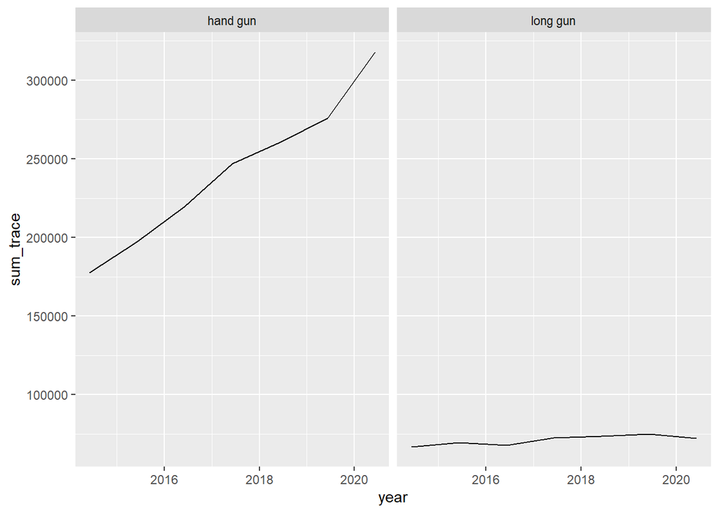

```r
year_total <- nation%>%
              group_by(year)%>%
              summarize(total=sum(value))

nati <- merge(x=tp_year_sum,y=year_total,by="year")%>%
        mutate(share=sum_trace/total)%>%
        drop_na()

ggplot(nati, aes(year,sum_trace)) +
  geom_line() +
  facet_wrap(vars(tp))
```

#### b. The share of traces per year nationally that are “hand guns” or “long guns”

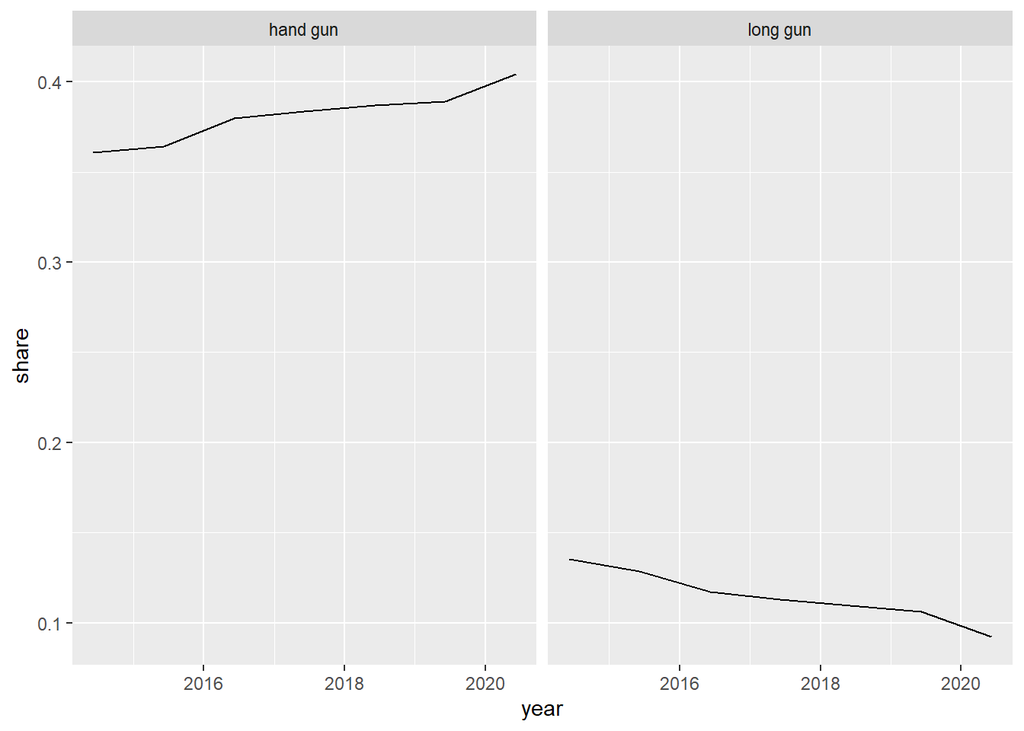

```r
ggplot(nati, aes(year,share)) +
  geom_line()+facet_wrap(vars(tp))
```

## 2 Collect NICS background check data

A second datastype_state that speaks to firearm prevalence in the US comes from the FBI: National Instant Criminal Background Check System (NICS).

### 1. In a couple of sentences describe the genesis of the NICS data. Who uses the NICS system and for what purpose?

NICS databases go back to 1998 when NICS was established. Their website claims that it conducted over 300 million checks, and issued more than 1.5 million denials. NICS databases contain numbers and results of background checks and the corresponding period.  
Legit firearms sellers, Federal Firearms Licensees (FFL), use the NICS system to ensure they don’t sell firearms to individuals who may endanger themselves and/or other members of the society. When someone wants to buy a firearm from a given FFL, that person must fill out the ATF form (ATF form). The licensed seller then contacts NICS to verify if the potential buyer is eligible to buy or own a firearm (i.e., if he/she does not have a criminal record, or is not ineligible in some other way, e.g., was not diagnosed with a mental disease, or does not have a record of drug abuse or domestic violence).

### 2.Plot the number of background checks by month during 2019.

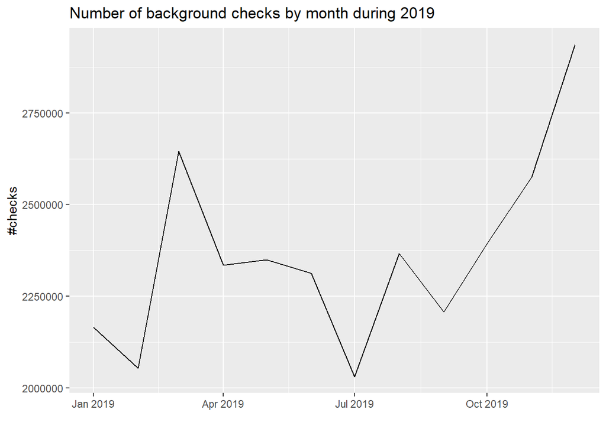

```r
nics_2019  <- read_excel("2019_month_NICS.xlsx", col_names=TRUE, sheet =2, range="A1:B13")

#add year and day
nics_2019$month<-paste("2019",nics_2019$Month,sep=" ",1)%>%str_trim()
#transform data type to date type
nics_2019<-nics_2019%>%
  mutate(date=as.Date(month, "%Y %b %d"))%>%
  mutate(value=as.numeric(Value))

ggplot(nics_2019, aes(date, value))+
  geom_line()+
  ggtitle("Number of background checks by month during 2019")+
  labs(x= "", y ="#checks")
```

## 3 Preliminary analysis

https://crime-data-explorer.app.cloud.gov/pages/explorer/crime/crime-trend ### 1. Download data on violent crime rates by state from the FBI Uniform Crime Report.

```r
viocrm  <- read_excel("table-5.xls", col_names=TRUE)
viocrm<-viocrm[,c(1,3,5)]

vc<-viocrm%>%fill(State)%>%filter(...3=="Rate per 100,000 inhabitants")%>%mutate(State=gsub('[0-9]+', '', State))%>%rename(state=State)

reg_data<-merge(vc,state_total_wide,by="state")%>%rename(crime="Violent \ncrime1", trace=value)
glimpse(reg_data)
```

```
## Rows: 52
## Columns: 4
## $ state <chr> "ALABAMA", "ALASKA", "ARIZONA", "ARKANSAS", "CALIFORNIA", "COLOR~
## $ ...3  <chr> "Rate per 100,000 inhabitants", "Rate per 100,000 inhabitants", ~
## $ crime <dbl> 510.8, 867.1, 455.3, 584.6, 441.2, 381.0, 183.6, 422.6, 1049.0, ~
## $ trace <dbl> 7674, 1133, 8983, 3516, 41883, 5637, 1423, 1224, 2134, 24068, 17~
```

### 2. Run a regression of state crime rates on the logarithm of the number of ATF traces. Create a clearly-labeled table with the regression output.

```r
lm1<-lm(formula = crime ~ log(trace),reg_data)
summary(lm1)
```

```
##
## Call:
## lm(formula = crime ~ log(trace), data = reg_data)
##
## Residuals:
##     Min      1Q  Median      3Q     Max
## -206.02 -102.86  -39.42   67.41  690.22
##
## Coefficients:
##             Estimate Std. Error t value Pr(>|t|)
## (Intercept)   102.33     156.03   0.656   0.5149
## log(trace)     33.45      18.88   1.772   0.0825 .
## ---
## Signif. codes:  0 '***' 0.001 '**' 0.01 '*' 0.05 '.' 0.1 ' ' 1
##
## Residual standard error: 174.2 on 50 degrees of freedom
## Multiple R-squared:  0.05909,    Adjusted R-squared:  0.04028
## F-statistic:  3.14 on 1 and 50 DF,  p-value: 0.08247
```

### 3. How would you interprete the coefficients that you estimate in 3.2? Your responses should be no longer than one paragraph.

```r
trace_change<-coef(lm1)["log(trace)"]/100
```